# Prepare Data from Forest Inventories

```r
source(here::here("load_pkgs.R"))
```

# MIGRAME

We downloaded the DarwinCore Archive (`.zip` file) of our dataset from GBIF ([doi: 10.15470/orboj4](https://doi.org/10.15470/orboj4)). Then, we use the `finch` package (Chamberlain 2019) to process the Darwin Core Archive and load the datasets.

```r
# x <- dwca_read("https://ipt.gbif.es/archive.do?r=migrame")
#
# mig_occ <- read_delim(x$data[1], delim = "\t")
# mig_mof <- read_delim(x$data[2], delim = "\t")

mig_occ <- read_delim(here::here("raw_data/migrame/dwca-migrame-v1.8/occurrence.txt"), delim = "\t", col_types = cols())
mig_mof <- read_delim(here::here("raw_data/migrame/dwca-migrame-v1.8/measurementorfact.txt"), delim = "\t", col_types = cols())


# Get transect data
# Transect data comes from Supplementary of https://doi.org/10.3897/phytokeys.56.5482

# Table S1. Information about transects of the project. Elevation in m a.s.l..
# Type: AM = Altitudinal migration; FO = Forest; MH = Marginal Habitat.
# Subtype:
#   AC-e = Abandoned Cropland: edge; AC-i = Abandoned Cropland: inside;
#   Pp-e = Pine plantations: edge; Pp-i: Pine plantations: inside;
#   TE = Treeline Ecotone.
# Locality: CA = Robledal de Cáñar; SJ = Robledal de San Juan.

mig_transectos <- read.table(here::here("raw_data/migrame/appendix_transects.csv"))

# Seleccionar datos de transectos dentro del robledal

fo <- mig_transectos %>%
  filter(type == "FO") %>% as.data.frame()
```

```
## filter: removed 168 rows (84%), 31 rows remaining
```

```r
# Prepare measurements
g <- mig_mof %>% dplyr::select(id, measurementType, measurementValue) %>%
  spread(measurementType, measurementValue) %>%
  rename(dbh = `diameter size`, h = `tree height`)
```

```
## spread: reorganized (measurementType, measurementValue) into (diameter size, tree height) [was 5751x3, now 3796x3]
```

```
## rename: renamed 2 variables (dbh, h)
```

```r
mig <- g %>% inner_join(mig_occ, by = "id") %>%
  mutate(loc = case_when(
             locality == "Robledal de San Juan. Barranco de San Juan" ~ "SJ",
             locality == "Robledal de Cañar. Loma de Cañar" ~ "CA")) %>%
  dplyr::select(id, dbh, h, eventDate, catalogNumber, loc, scientificName) %>%
  separate(catalogNumber, c(NA, "tr", NA), sep ="-") %>%
  filter(tr %in% unique(fo$name)) %>%
  mutate(sp = case_when(
    scientificName == "Quercus pyrenaica Willd." ~ "Qpyr",
    scientificName == "Quercus ilex L. subsp. ballota" ~ "Qilex"
  ))
```

```
## inner_join: added 34 columns (modified, language, institutionCode, collectionCode, basisOfRecord, …)
```

```
##             > rows only in x  (    0)
```

```
##             > rows only in y  (   43)
```

```
##             > matched rows     3,796
```

```
##             >                 =======
```

```
##             > rows total       3,796
```

```
## mutate: new variable 'loc' with 2 unique values and 0% NA
```

```
## filter: removed 2,280 rows (60%), 1,516 rows remaining
```

```
## mutate: new variable 'sp' with 2 unique values and 0% NA
```

```r
mig %<>%
  mutate(h = h/100,
         hval = "field",
         project = "migrame") %>%
  dplyr::select(code = tr, sp, dbh, h, hval, project)
```

```
## mutate: changed 1,514 values (>99%) of 'h' (0 new NA)
```

```
##         new variable 'hval' with one unique value and 0% NA
```

```
##         new variable 'project' with one unique value and 0% NA
```

```r
# Filter data
# cuantos ind sin diámetro?
mig %>% filter(is.na(dbh)) %>% group_by(sp) %>% count()
```

```
## filter: removed 974 rows (64%), 542 rows remaining
```

```
## group_by: one grouping variable (sp)
```

```
## count: now 2 rows and 2 columns, one group variable remaining (sp)
```

```
## # A tibble: 2 x 2
## # Groups:   sp [2]
##   sp        n
##   <chr> <int>
## 1 Qilex    36
## 2 Qpyr    506
```

```r
# Maxima h
mig %>% filter(is.na(dbh)) %>% summarise(hmax = max(h))
```

```
## filter: removed 974 rows (64%), 542 rows remaining
```

```
## summarise: now one row and one column, ungrouped
```

```
## # A tibble: 1 x 1
##    hmax
##   <dbl>
## 1  2.05
```

```
## filter: removed 542 rows (36%), 974 rows remaining
```

```
## filter: removed one row (<1%), 973 rows remaining
```

```
## filter: removed 701 rows (72%), 272 rows remaining
```

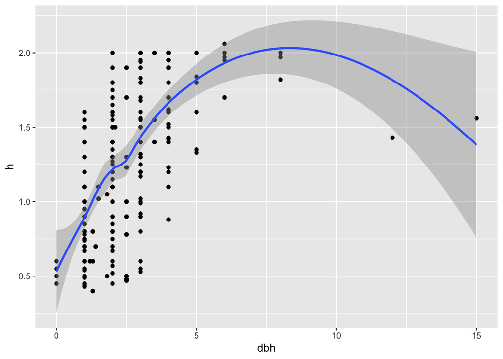

```r
# Estimar datos de diámetro para valores h < 2.1
## ploteo
mig %>%
  filter(!is.na(dbh)) %>%
  filter(sp == "Qpyr") %>%
  filter(h < 2.1) %>%
  ggplot(aes(x=dbh, y = h)) +
  geom_point() +
  geom_smooth()
```

```r
##  Elimino outliers: aquellos valores de h < 2.1 con dbh > 10
mig %<>% filter(!(dbh %in% c(12,15) & h < 2.1))
```

```
## filter: removed 2 rows (<1%), 1,514 rows remaining
```

```r
## Elimino datos con dbh = 0
mig %<>% filter(!(dbh == 0) | is.na(dbh))
```

```
## filter: removed 6 rows (<1%), 1,508 rows remaining
```

```r
# Creo subset de datos con
mig_h2 <- mig %>%
  filter(sp == "Qpyr") %>%
  filter(!is.na(dbh) & h < 2.1)
```

```
## filter: removed 37 rows (2%), 1,471 rows remaining
```

```
## filter: removed 1,207 rows (82%), 264 rows remaining
```

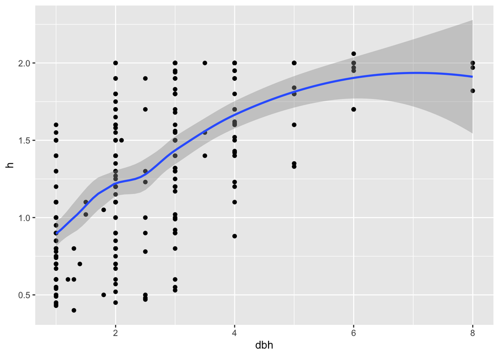

```r
mig_h2 %>%
 ggplot(aes(x=dbh, y = h)) +
  geom_point() +
  geom_smooth()
```

```r
# Computar modelo de dbh para los datos de h < 2.1
m_dbh <- nls(dbh ~ a + b * exp(h),
         data = mig_h2,
         start = list(a=0.1, b=0.1), trace = TRUE)
```

```
## 1485.674 :  0.1 0.1
## 303.6746 :  0.4655420 0.5061868
```

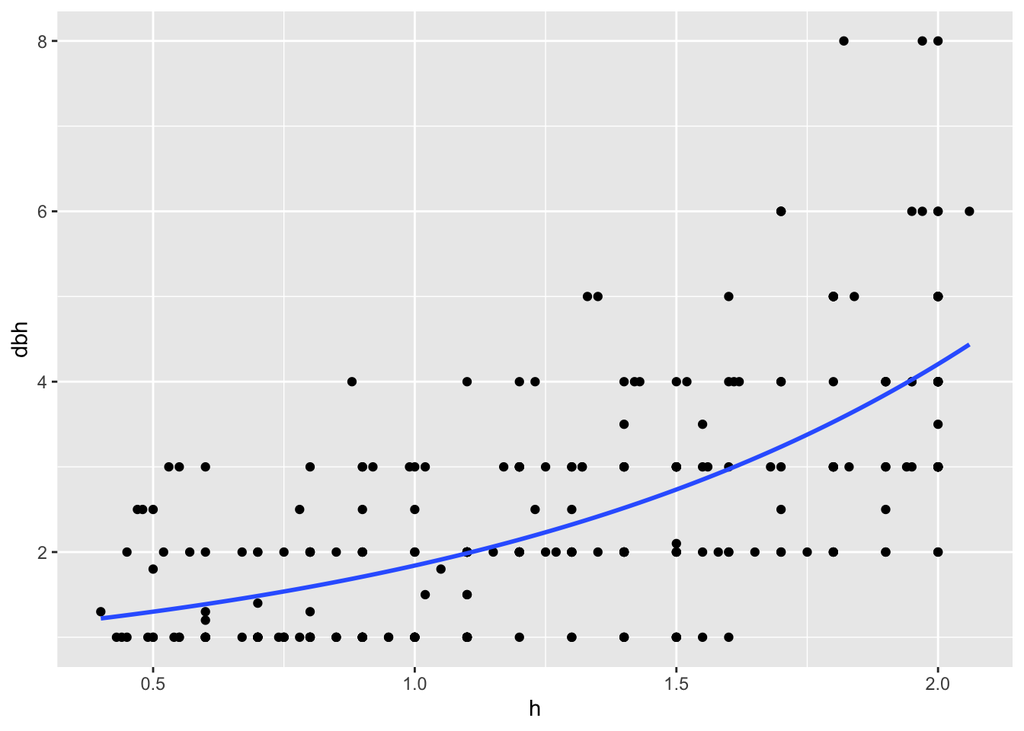

```r
mig_h2 %>%
 ggplot(aes(y=dbh, x = h)) +
  geom_point() +
  geom_smooth(method="nls",
              formula=y~a+b*exp(x),
              method.args = list(start=c(a=0.5,b=0.45)),
              se = FALSE)
```

```r
# Estimar valores de dbh para datos de h < 2.1
mig_Data <- mig %<>%
  mutate(dval = case_when(
    is.na(dbh) ~ "est",
    TRUE ~ "field")) %>%
  mutate(dbh =
        ifelse(is.na(dbh) & sp == "Qpyr",
             round((coef(m_dbh)[1] + coef(m_dbh)[2] * exp(h)), 2),
             dbh))
```

```
## mutate: new variable 'dval' with 2 unique values and 0% NA
```

```
## mutate: changed 506 values (34%) of 'dbh' (506 fewer NA)
```

Notas: - *Q. ilex* records - n = 37 - 36 records h < 0.8 - 1 record h = 1.44

Remove Q. ilex data from migrame

```r
mig_Data %<>% filter(sp != "Qilex")
```

```
## filter: removed 37 rows (2%), 1,471 rows remaining
```

¿Todos los datos de mig completos?

```r
mig_Data %>% filter(is.na(h)) %>% count()
```

```
## filter: removed 1,469 rows (>99%), 2 rows remaining
```

```
## count: now one row and one column, ungrouped
```

```
## # A tibble: 1 x 1
##       n
##   <int>
## 1     2
```

```r
# Read spatial info
mig_spa <- rgdal::readOGR(dsn = here::here("/raw_data/geoinfo"),
                   layer = "mig_transectos_polygon",
                   verbose = TRUE, encoding = "UTF-8")
# Select transects and variables
mig_spaFO <- subset(mig_spa, nombre %in% unique(fo$name))
mig_spaFO <- mig_spaFO[, c("nombre", "fecha")]
names(mig_spaFO) <- c("code", "date")
```

```r
rm(list = setdiff(ls(), c("mig_Data", "mig_spaFO")))
```

# Dendro SN

- Data from Pérez-Luque et al. (Submitted to *Ecosystems*).
- 50 target trees were cored for dendrochronological analysis
- Stand competition of target trees was assessed by recording distance, azimuth, DBH, species and total height of all neighboring living trees with DBH > 7.5 cm within a circular plot of 10 m radius.

```r
# Read spatial info
dendrosn_spa <- rgdal::readOGR(dsn = here::here("/raw_data/geoinfo"),
                   layer = "dendro_sn_polygon",
                   verbose = TRUE, encoding = "UTF-8")
dendrosn_spa <- dendrosn_spa[, c("name", "cmt")]

dendrosn_spa@data$date <- parse_date(str_sub(dendrosn_spa@data$cmt, end=-10))
dendrosn_spa <- dendrosn_spa[, c("name", "date")]
names(dendrosn_spa)[1] <- "code"

dendrosn_Data <- read_csv(here::here("raw_data/dendro_sn/dendro_competence.csv")) %>%
  dplyr::select(code = id_focal, sp, perim_mm, h = height_cm) %>%
  filter(code != "Fresno") %>%
  mutate(sp = case_when(
    sp == "Focal" ~ "Qpyr",
    TRUE ~ as.character(sp))) %>%
  mutate(dbh = round((perim_mm / 10)/pi,2),
         h = h / 100, # as meter
         hval = "field",
         project = "dendro_sn") %>%
  dplyr::select(-perim_mm)
```

```
## filter: removed one row (<1%), 620 rows remaining
```

```
## mutate: changed 50 values (8%) of 'sp' (0 new NA)
```

```
## mutate: changed 620 values (100%) of 'h' (0 new NA)
```

```
##         new variable 'dbh' with 224 unique values and 0% NA
```

```
##         new variable 'hval' with one unique value and 0% NA
```

```
##         new variable 'project' with one unique value and 0% NA
```

```r
dendrosn_Data %>% group_by(sp) %>% count()
```

```
## group_by: one grouping variable (sp)
```

```
## count: now 4 rows and 2 columns, one group variable remaining (sp)
```

```
## # A tibble: 4 x 2
## # Groups:   sp [4]
##   sp        n
##   <chr> <int>
## 1 Cmon     16
## 2 Pdul      9
## 3 Pter      9
## 4 Qpyr    586
```

```r
dendrosn_Data %<>% mutate(dval = "field")
```

```
## mutate: new variable 'dval' with one unique value and 0% NA
```

# Dendro LIFE

- Data from monitoring dendro LIFE-ADAPTAMED
- Several plots in Pyrenean oaks forest with variable size
- Distance, azimuth, DBH, species and height of all living trees within a circular plot of variable radius were registered.

```r
# Read spatial info
dendrolife_spa <- rgdal::readOGR(dsn = here::here("/raw_data/geoinfo"),
                   layer = "dendro_life_polygon",
                   verbose = TRUE, encoding = "UTF-8")
dendrolife_spa <- dendrolife_spa[, c("code", "date")]
dendrolife_spa@data$date <- parse_date(dendrolife_spa@data$date)
dendrolife_spa <- subset(dendrolife_spa, code != "PORTUGOS_X")

dendrolife_Data <- read_csv(here::here("raw_data/dendro_life/dendro_life.csv")) %>%
  mutate(sp = case_when(
    specie == "Quercus pyrenaica" ~ "Qpyr",
    TRUE ~ "Qilex"),
    hval = "field",
    project = "dendro_life") %>%
  dplyr::select(code = loc, sp, dbh = dbh1_cm, h = treeHeight_m, hval, project)
```

```
## mutate: new variable 'sp' with 2 unique values and 0% NA
```

```
##         new variable 'hval' with one unique value and 0% NA
```

```
##         new variable 'project' with one unique value and 0% NA
```

```r
# Remove mixed stands
dendrolife_Data %<>% filter(code != "PORTUGOS_X")
```

```
## filter: removed 41 rows (17%), 196 rows remaining
```

```r
# Remove records without measures
dendrolife_Data %<>% filter(!(is.na(dbh) & is.na(h)))
```

```
## filter: removed 5 rows (3%), 191 rows remaining
```

```r
# Estimate dbh

## ¿h max de los datos sin dbh?
dendrolife_Data %>%
  filter(is.na(dbh)) %>% summarise(max(h))
```

```
## filter: removed 92 rows (48%), 99 rows remaining
```

```
## summarise: now one row and one column, ungrouped
```

```
## # A tibble: 1 x 1
##   `max(h)`
##      <dbl>
## 1      4.7
```

```r
## subset datos con dbh
d5 <- dendrolife_Data %>%
  filter(!is.na(dbh)) %>%
  filter(h < 5)
```

```
## filter: removed 99 rows (52%), 92 rows remaining
```

```
## filter: removed 59 rows (64%), 33 rows remaining
```

```r
# Computar modelo de dbh para los datos de h < 2.1
m_d <- nls(dbh ~ a + b * exp(h),
         data = d5,
         start = list(a=2, b=1), trace = TRUE)
```

```
## 85563.54 :  2 1
## 90.52013 :  3.3365294 0.0386336
```

```r
summary(m_d)
```

```
##
## Formula: dbh ~ a + b * exp(h)
##
## Parameters:
##   Estimate Std. Error t value Pr(>|t|)
## a 3.336529   0.430484   7.751 9.60e-09 ***
## b 0.038634   0.007982   4.840 3.39e-05 ***
## ---
## Signif. codes:  0 '***' 0.001 '**' 0.01 '*' 0.05 '.' 0.1 ' ' 1
##
## Residual standard error: 1.709 on 31 degrees of freedom
##
## Number of iterations to convergence: 1
## Achieved convergence tolerance: 1.781e-08
```

```r
# Estimar valores de dbh para datos de h < 5
dendrolife_Data %<>%
  mutate(dval = case_when(
    is.na(dbh) ~ "est",
    TRUE ~ "field")) %>%
  mutate(dbh =
        ifelse(is.na(dbh),
             round((coef(m_d)[1] + coef(m_d)[2] * exp(h)), 2),
             dbh))
```

```
## mutate: new variable 'dval' with 2 unique values and 0% NA
```

```
## mutate: changed 99 values (52%) of 'dbh' (99 fewer NA)
```

```r
rm("d5", "m_d")
```

# Robledal LIFE

- Parcelas de CANAR = robledal puro. PORTUGOS = robledal-encinar
- Solamente 5 árboles tipo por plot
- Estimar h por ecuación

```r
# list ods files
ods_file_names <- here::here("raw_data/robledal_life/") %>%
  list.files() %>%
  .[str_detect(., ".ods")]

# Read tree data
df_dbh <- ods_file_names %>%
  purrr::map_dfr(function(file_name){ # iterate through each file name
    daso <- read_ods(paste0(here::here("raw_data/robledal_life/"), file_name),
                          sheet = "1_DASOMETRICO", col_types = cols()) %>%
      as_tibble(.name_repair = "unique") %>% # Name variable col 7
      mutate(code = str_remove(file_name, "_c1_forestal.ods"))
    }) %>%
  filter(is.na(`...7`)) %>%
  dplyr::select(-CUADRANTE, sp = ESPECIE, -`...7`,
                dbh1 = "Dnor (cm) 1", dbh2 = "Dnor (cm) 2",
                dbase1 ="Dbas (cm) 1", dbase2 = "Dbas (cm) 2")
```

```
## * `` -> ...7
```

```
## mutate: new variable 'code' with one unique value and 0% NA
```

```
## * `` -> ...7
```

```
## mutate: new variable 'code' with one unique value and 0% NA
```

```
## * `` -> ...7
```

```
## mutate: new variable 'code' with one unique value and 0% NA
```

```
## * `` -> ...7
```

```
## mutate: new variable 'code' with one unique value and 0% NA
```

```
## * `` -> ...7
```

```
## mutate: new variable 'code' with one unique value and 0% NA
```

```
## * `` -> ...7
```

```
## mutate: new variable 'code' with one unique value and 0% NA
```

```
## * `` -> ...7
```

```
## mutate: new variable 'code' with one unique value and 0% NA
```

```
## * `` -> ...7
```

```
## mutate: new variable 'code' with one unique value and 0% NA
```

```
## * `` -> ...7
```

```
## mutate: new variable 'code' with one unique value and 0% NA
```

```
## * `` -> ...7
```

```
## mutate: new variable 'code' with one unique value and 0% NA
```

```
## * `` -> ...7
```

```
## mutate: new variable 'code' with one unique value and 0% NA
```

```
## * `` -> ...7
```

```
## mutate: new variable 'code' with one unique value and 0% NA
```

```
## * `` -> ...7
```

```
## mutate: new variable 'code' with one unique value and 0% NA
```

```
## * `` -> ...7
```

```
## mutate: new variable 'code' with one unique value and 0% NA
```

```
## * `` -> ...7
```

```
## mutate: new variable 'code' with one unique value and 0% NA
```

```
## * `` -> ...7
```

```
## mutate: new variable 'code' with one unique value and 0% NA
```

```
## * `` -> ...7
```

```
## mutate: new variable 'code' with one unique value and 0% NA
```

```
## * `` -> ...7
```

```
## mutate: new variable 'code' with one unique value and 0% NA
```

```
## * `` -> ...7
```

```
## mutate: new variable 'code' with one unique value and 0% NA
```

```
## * `` -> ...7
```

```
## mutate: new variable 'code' with one unique value and 0% NA
```

```
## * `` -> ...7
```

```
## mutate: new variable 'code' with one unique value and 0% NA
```

```
## * `` -> ...7
```

```
## mutate: new variable 'code' with one unique value and 0% NA
```

```
## * `` -> ...7
```

```
## mutate: new variable 'code' with one unique value and 0% NA
```

```
## * `` -> ...7
```

```
## mutate: new variable 'code' with one unique value and 0% NA
```

```
## filter: removed 152 rows (13%), 984 rows remaining
```

```r
df_aux <- df_dbh %>%
   mutate(sp = case_when(
    sp == "Quercus pyrenaica" ~ "Qpyr",
    sp == "Quercus ilex" ~ "Qilex"),
    h = NA, hval = "est", project = "robledal_life") %>%
  rowwise() %>%
  mutate(dbh = max(c(dbh1, dbh2))) %>%
  dplyr::select(code, sp, dbh, h, hval, project) %>%
  filter(str_detect(code, "CAN"))
```

```
## mutate: changed 984 values (100%) of 'sp' (0 new NA)
```

```
##         new variable 'h' with one unique value and 100% NA
```

```
##         new variable 'hval' with one unique value and 0% NA
```

```
##         new variable 'project' with one unique value and 0% NA
```

```
## mutate: new variable 'dbh' with 177 unique values and 0% NA
```

```
## filter: removed 411 rows (42%), 573 rows remaining
```

```r
# Read tipo data
df_tipo <- ods_file_names %>%
  purrr::map_dfr(function(file_name){
    daso <- read_ods(paste0(here::here("raw_data/robledal_life/"), file_name),
                          sheet = "2_EJEMPLARES_TIPO", col_types = cols()) %>%
      as_tibble(.name_repair = "unique") %>% # Name variable col 7
      mutate(code = str_remove(file_name, "_c1_forestal.ods"))
    }) %>%
   dplyr::select(sp = Especie, h = "Altura (m)",
                dbh1 = "D.nor (cm) 1", dbh2 = "D.nor (cm) 2",
                dbase1 ="D.bas (cm) 1", dbase2 = "D.bas (cm) 2",
                code)
```

```
## mutate: new variable 'code' with one unique value and 0% NA
```

[output not shown]

```r
df_auxtipo <- df_tipo %>%
   mutate(sp = case_when(
    sp == "Quercus pyrenaica" ~ "Qpyr"),
    hval = "field", project = "robledal_life") %>%
  rowwise() %>%
  mutate(dbh = max(c(dbh1, dbh2))) %>%
  dplyr::select(code, sp, dbh, h, hval, project) %>%
  filter(str_detect(code, "CAN"))
```

```
## mutate: changed 155 values (100%) of 'sp' (40 new NA)
```

```
##         new variable 'hval' with one unique value and 0% NA
```

```
##         new variable 'project' with one unique value and 0% NA
```

```
## mutate: new variable 'dbh' with 95 unique values and 0% NA
```

```
## filter: removed 75 rows (48%), 80 rows remaining
```

```r
robledal_lifeData <- df_aux %>% rbind(df_auxtipo) %>% as.data.frame()




# Cuantas sps?
robledal_lifeData %>% group_by(sp) %>% count()
```

```
## group_by: one grouping variable (sp)
```

```
## count: now 2 rows and 2 columns, one group variable remaining (sp)
```

```
## # A tibble: 2 x 2
## # Groups:   sp [2]
##   sp        n
##   <chr> <int>
## 1 Qilex     3
## 2 Qpyr    650
```

```r
# Q.ilex
robledal_lifeData %>% filter(sp == "Qilex")
```

```
## filter: removed 650 rows (>99%), 3 rows remaining
```

```
##         code    sp dbh  h hval       project
## 1 CAN_RES_38 Qilex 8.2 NA  est robledal_life
## 2 CAN_RES_38 Qilex 8.3 NA  est robledal_life
## 3 CAN_RES_38 Qilex 9.9 NA  est robledal_life
```

```r
# How many full records for Q. pyr
robledal_lifeData %>% filter(sp == "Qpyr") %>%
  group_by(hval) %>% count()
```

```
## filter: removed 3 rows (<1%), 650 rows remaining
```

```
## group_by: one grouping variable (hval)
```

```
## count: now 2 rows and 2 columns, one group variable remaining (hval)
```

```
## # A tibble: 2 x 2
## # Groups:   hval [2]
##   hval      n
##   <chr> <int>
## 1 est     570
## 2 field    80
```

```r
robledal_lifeData %<>% mutate(dval = "field")
```

```
## mutate: new variable 'dval' with one unique value and 0% NA
```

```r
# Read spatial info
robledal_lifespa <- rgdal::readOGR(dsn = here::here("/raw_data/geoinfo"),
                   layer = "robledal_life_polygon",
                   verbose = TRUE, encoding = "UTF-8")
robledal_lifespa <- robledal_lifespa[, c("code", "date")]
# Solve problems with naming
robledal_lifespa@data$code <- gsub("-", "_", robledal_lifespa@data$code)
robledal_lifespa@data$date <- parse_date(robledal_lifespa@data$date)


rm("df_aux", "df_auxtipo", "df_dbh", "df_tipo")
```

# OBSNEV San Jeronimo

- 9 parcelas en el robledal de San Jerónimo
- 3 réplicas x 3 tratamientos (Control / Moderado / Intenso)
  - Control: No actuación. Parcelas de 20 x 20 m. En ellas se toman los datos de 10 individuos (distancia al centro; rumbo; dbh; diametro basal; altura) y también se toman datos del resto de individuos (diámetro basal y dbh)
  - Moderada: Eliminación de pies secos/enfermos, y los incluidos en una agrupación (conjunto de robles que distan entre sí menos de 3 m.) y que tengan un diámetro basal < 15 cm.
  - Intenso: idem moderada + incremento de corta hasta 30 % seleccionándose para ello los pies enfermos, dominados y/o excesivamente densos, eliminándose en este último caso alguno de los pies que estén más próximos.

### Inconvenientes / DUDAS:

- Solamente las parcelas control no fueron tratadas, por lo que tendríamos solamente 3 parcelas.
- De las otras, siempre tendríamos en torno al centroide 10 árboles localizados (con todas sus medidas)
- De las parcelas control, solamente tenemos datos completos de 10 árboles. Del resto de los árboles de la parcela tenemos datos de diámetros. Podemos no utilizarlos o realizar una estimación de la altura a partir de ecuaciónes de regresión.

```r
# Read spatial info
obsnev_sjer <- rgdal::readOGR(dsn = here::here("/raw_data/geoinfo"),
                   layer = "obsnev_sjeronimo_polygon",
                   verbose = TRUE, encoding = "UTF-8")
obsnev_sjer <- obsnev_sjer[, c("code", "fecha")]
names(obsnev_sjer)[2] <- "date"
obsnev_sjer@data$date <- parse_date(obsnev_sjer@data$date)



# Data
j <- readxl::read_xlsx(
  here::here("raw_data/obs_sanjeronimo/san_jeronimo_cleaned.xlsx")) %>%
  rowwise() %>%
  mutate(dbh = max(c(Dn1, Dn2)),
         project = "obsnev_sjer",
         sp = recode(especie, "Quercus pyrenaica" = "Qpyr")) %>%
  as.data.frame()
```

```
## mutate: new variable 'dbh' with 30 unique values and 0% NA
```

```
##         new variable 'project' with one unique value and 0% NA
```

```
##         new variable 'sp' with one unique value and 0% NA
```

```r
# Get only Data of "tipo" trees from all plots
j_tipo <- j %>%
  filter(!is.na(tipo)) %>%
  rowwise() %>%
  mutate(h = max(c(h1, h2, htot), na.rm = TRUE)) %>%
  filter(h != -Inf) %>%
  mutate(hval = "field") %>%
  dplyr::select(code, sp, dbh, h, hval, project) %>%
  as.data.frame()
```

```
## filter: removed 336 rows (79%), 90 rows remaining
```

```
## mutate: new variable 'h' with 59 unique values and 0% NA
```

```
## filter: removed one row (1%), 89 rows remaining
```

```
## mutate: new variable 'hval' with one unique value and 0% NA
```

```r
# Get other data
j_all <- j %>%
  filter(is.na(tipo)) %>%
  mutate(h = NA, hval = "est") %>%
  dplyr::select(code, sp, dbh, h, hval, project)
```

```
## filter: removed 90 rows (21%), 336 rows remaining
```

```
## mutate: new variable 'h' with one unique value and 100% NA
```

```
##         new variable 'hval' with one unique value and 0% NA
```

```r
obsnev_sjerData <- j_all %>% rbind(j_tipo)

obsnev_sjerData %<>%
  filter(code %in% c("A-3", "B-3", "C-3")) %>%
  mutate(dval = "field")
```

```
## filter: removed 303 rows (71%), 122 rows remaining
```

```
## mutate: new variable 'dval' with one unique value and 0% NA
```

```r
obsnev_sjerData %>% group_by(hval) %>% count()
```

```
## group_by: one grouping variable (hval)
```

```
## count: now 2 rows and 2 columns, one group variable remaining (hval)
```

```
## # A tibble: 2 x 2
## # Groups:   hval [2]
##   hval      n
##   <chr> <int>
## 1 est      92
## 2 field    30
```

```r
rm("j", "j_all", "j_tipo")
```

### SINFONEVADA

We downloaded the DarwinCore Archive (`.zip` file) of our dataset from GBIF ([doi: 10.15468/4gpr7e](https://doi.org/10.15468/4gpr7e)). Then, we use the `finch` package (Chamberlain 2019) to process the Darwin Core Archive and load the datasets.

```r
# sinfodwca  <- dwca_read("https://ipt.gbif.es/archive.do?r=sinfonevada&v=1.5")
# sinfo_occ <- read_delim(sinfodwca$data[1], delim = "\t")

sinfo_occ <- read_delim(here::here("raw_data/sinfonevada/dwca-sinfonevada-v1.5/occurrence.txt"), delim = "\t", col_types = cols())

sinfo_plots <- sinfo_occ %>%
  separate(catalogNumber, c(NA,"id_parcela", NA, NA), sep = "-") %>%
  mutate(id_parcela = as.numeric(id_parcela)) %>%
  dplyr::select(id_parcela, decimalLatitude, decimalLongitude)

sinfo_aux <- read_csv(here::here("raw_data/sinfonevada/parcelas_sinfo_qp.csv"), col_types = cols())


sinfo_qp <- sinfo_plots %>%
  inner_join(sinfo_aux, by="id_parcela")

sinfo_qp_spa <- SpatialPointsDataFrame(coords = sinfo_qp[,c("decimalLongitude","decimalLatitude")],
                                       data = sinfo_qp,
                                       proj4string = CRS("+init=epsg:4326"))
```

- Each inventory plot has three sampling ts: i) a forest inventory plot (20 × 20 m); ii) a 5-m radius subplot for the estimation of the regeneration; iii) and a 10-m radius subplot for species composition and abundance. Each live tree with a diameter at breast height (dbh) > 7.5 cm was tallied by species and dbh in the forest inventory plot.
- Tenemos datos del centroide pero no del polígono.

### QP_DASOMETRICO

- Parcelas realizadas en varias de las poblaciones de robledal especificamente para caracterizar la estructura. Se han hecho muestreos en Durcal, Dilar, POrtugos y Pampaneira

```r
# Read spatial info
qp_dasometrico <- rgdal::readOGR(dsn = here::here("/raw_data/geoinfo"),
                   layer = "qp_dasometrico_polygon",
                   verbose = TRUE, encoding = "UTF-8")
```

```r
qp_dasometrico@data$date <- parse_date(qp_dasometrico@data$date)

# Data
qp_dasometricoData <- read_csv(here::here("raw_data/daso_life/qp_dasometrico_tree_data.csv"), col_types = cols()) %>%
  filter(dis < 16) %>%
   mutate(sp = case_when(
    sp == "Quercus pyrenaica" ~ "Qpyr",
    sp == "Acer opalus granatensis" ~ "Aopa",
    sp == "Sorbus aria" ~ "Saria",
    sp == "Adenocarpus decorticans" ~ "Adec",
    TRUE ~ "Cmon"),
    hval = "field",
    dval = "field",
    project = "qp_dasometrico") %>%
  dplyr::select(code = plot, sp, dbh = dbh, h = height, hval, project)
```

```
## filter: removed 7 rows (2%), 428 rows remaining
```

```
## mutate: changed 428 values (100%) of 'sp' (0 new NA)
```

```
##         new variable 'hval' with one unique value and 0% NA
```

```
##         new variable 'dval' with one unique value and 0% NA
```

```
##         new variable 'project' with one unique value and 0% NA
```

```r
qp_dasometricoData %>% group_by(sp) %>% count()
```

```
## group_by: one grouping variable (sp)
```

```
## count: now 5 rows and 2 columns, one group variable remaining (sp)
```

```
## # A tibble: 5 x 2
## # Groups:   sp [5]
##   sp        n
##   <chr> <int>
## 1 Adec      1
## 2 Aopa      6
## 3 Cmon     21
## 4 Qpyr    382
## 5 Saria    18
```

- Eliminar > 16 m distancia en CAM2

# Unir capas

```r
# Check projection and if not 4326 transform

# CRS("+init=epsg:4326")
p <-projection(obsnev_sjer)

qp_dasometrico <- spTransform(qp_dasometrico, p)
mig_spaFO <- spTransform(mig_spaFO, p)
dendrosn_spa<- spTransform(dendrosn_spa, p)
dendrolife_spa<- spTransform(dendrolife_spa, p)
robledal_lifespa <- spTransform(robledal_lifespa, p)


plotsQP <- rbind(dendrolife_spa, dendrosn_spa,
           mig_spaFO, qp_dasometrico, obsnev_sjer, robledal_lifespa,
           makeUniqueIDs = TRUE)
```

## Filtrado datos espaciales

- Visualización para ver solapes
- Creamos variable selected
- Indicamos motivo no selected

```r
# Add data
dicc_plot <- read_csv(here::here("raw_data/dicc_plots.csv"), col_types = cols())

plotsQP <- merge(plotsQP, dicc_plot, by.x ="code", by.y="original_code")

tt <- plotsQP@data

writeOGR(plotsQP,
         dsn = here::here("/data/geoinfo"),
         "plotsQP", driver="ESRI Shapefile", overwrite_layer = TRUE)
```

### ¿Cuantos plots selecionados?

```r
plotsQP@data %>% dplyr::group_by(selected) %>% count()
```

```
## count: now 2 rows and 2 columns, one group variable remaining (selected)
```

```
## # A tibble: 2 x 2
## # Groups:   selected [2]
##   selected     n
##   <lgl>    <int>
## 1 FALSE       12
## 2 TRUE       113
```

```r
plotsQP_selected <- subset(plotsQP, selected == "TRUE")

writeOGR(plotsQP_selected,
         dsn = here::here("/data/geoinfo"),
         "plotsQP_selected", driver="ESRI Shapefile", overwrite_layer = TRUE)
```

# Visualize plots and Q. pyrenaica forests

- Read Q. pyrenaica forests

```r
qp_sn <- rgdal::readOGR(dsn="/Users/ajpelu/Google Drive/_phd/qpyr_distribution/data_raw/geoinfo/",
                    layer = 'q_pyr_sn_4326', verbose = TRUE, encoding = "UTF-8")
qp_sn25 <- rgdal::readOGR(dsn="/Users/ajpelu/Google Drive/_phd/qpyr_distribution/data_raw/geoinfo/",
                    layer = 'q_pyr_sn25830', verbose = TRUE, encoding = "UTF-8")
```

```r
qpR <- spTransform(qp_sn25, CRS("+init=epsg:4326"))

mapview::mapview(qpR, color = "red", col.regions = "red", lwd = 1) + mapview::mapview(plotsQP_selected, color = "blue", clo.regions = "blue")
```

[interactive chart not shown]

# Generar datos

```r
tree <-  bind_rows(
  list(mig_Data, dendrolife_Data, dendrosn_Data, qp_dasometricoData, obsnev_sjerData, robledal_lifeData))

write_csv(tree, here::here("data/tree_data.csv"))
```

A total of 3485 trees in our dataset. Trees by project:

```r
tree %>% group_by(project) %>% count() %>% knitr::kable()
```

| project | n |
| --- | --- |
| dendro_life | 191 |
| dendro_sn | 620 |
| migrame | 1471 |
| obsnev_sjer | 122 |
| qp_dasometrico | 428 |
| robledal_life | 653 |

# References

Chamberlain, Scott. 2019. *Finch: Parse Darwin Core Files*. https://CRAN.R-project.org/package=finch.